# Análise preditiva conjunto de dados Carseats

Lucas Marra

06/07/2020

### **Bibliotecas e pacotes utilizados**

```r
library(ISLR)
library(tidyverse)
library(tidymodels)
library(broom)
library(doParallel)
library(vip)
library(ranger)
library(dplyr)
library(skimr)
library(naniar)
library(leaps)
library(doParallel)
library(kknn)
```

### **Base de estudo**

A base a ser trabalhada será a *Carseats* (regressão), sendo “Advertising” a variável resposta.

```r
head(Carseats)
```

```
##   Sales CompPrice Income Advertising Population Price ShelveLoc Age Education
## 1  9.50       138     73          11        276   120       Bad  42        17
## 2 11.22       111     48          16        260    83      Good  65        10
## 3 10.06       113     35          10        269    80    Medium  59        12
## 4  7.40       117    100           4        466    97    Medium  55        14
## 5  4.15       141     64           3        340   128       Bad  38        13
## 6 10.81       124    113          13        501    72       Bad  78        16
##   Urban  US
## 1   Yes Yes
## 2   Yes Yes
## 3   Yes Yes
## 4   Yes Yes
## 5   Yes  No
## 6    No Yes
```

### **Exploração dos dados**

Visualização dos tipos de variáveis do conjunto de dados.

```r
glimpse(Carseats)
```

```
## Observations: 400
## Variables: 11
## $ Sales       <dbl> 9.50, 11.22, 10.06, 7.40, 4.15, 10.81, 6.63, 11.85, 6.5...
## $ CompPrice   <dbl> 138, 111, 113, 117, 141, 124, 115, 136, 132, 132, 121, ...
## $ Income      <dbl> 73, 48, 35, 100, 64, 113, 105, 81, 110, 113, 78, 94, 35...
## $ Advertising <dbl> 11, 16, 10, 4, 3, 13, 0, 15, 0, 0, 9, 4, 2, 11, 11, 5, ...
## $ Population  <dbl> 276, 260, 269, 466, 340, 501, 45, 425, 108, 131, 150, 5...
## $ Price       <dbl> 120, 83, 80, 97, 128, 72, 108, 120, 124, 124, 100, 94, ...
## $ ShelveLoc   <fct> Bad, Good, Medium, Medium, Bad, Bad, Medium, Good, Medi...
## $ Age         <dbl> 42, 65, 59, 55, 38, 78, 71, 67, 76, 76, 26, 50, 62, 53,...
## $ Education   <dbl> 17, 10, 12, 14, 13, 16, 15, 10, 10, 17, 10, 13, 18, 18,...
## $ Urban       <fct> Yes, Yes, Yes, Yes, Yes, No, Yes, Yes, No, No, No, Yes,...
## $ US          <fct> Yes, Yes, Yes, Yes, No, Yes, No, Yes, No, Yes, Yes, Yes...
```

Plot das variáveis

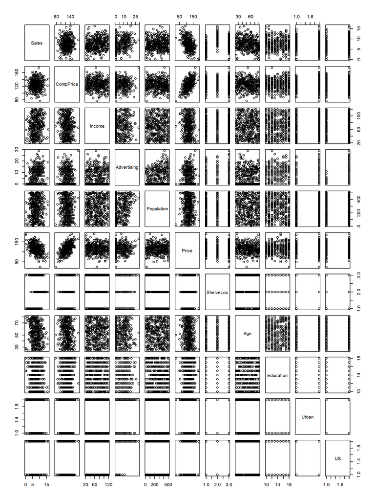

```r
plot(Carseats)
```

Overview sumarizado do conjunto de dados

```r
skim(Carseats)
```

Data summary

| Name | Carseats |
| --- | --- |
| Number of rows | 400 |
| Number of columns | 11 |
| _______________________ |  |
| Column type frequency: |  |
| factor | 3 |
| numeric | 8 |
| ________________________ |  |
| Group variables | None |

**Variable type: factor**

| skim_variable | n_missing | complete_rate | ordered | n_unique | top_counts |
| --- | --- | --- | --- | --- | --- |
| ShelveLoc | 0 | 1 | FALSE | 3 | Med: 219, Bad: 96, Goo: 85 |
| Urban | 0 | 1 | FALSE | 2 | Yes: 282, No: 118 |
| US | 0 | 1 | FALSE | 2 | Yes: 258, No: 142 |

**Variable type: numeric**

| skim_variable | n_missing | complete_rate | mean | sd | p0 | p25 | p50 | p75 | p100 | hist |
| --- | --- | --- | --- | --- | --- | --- | --- | --- | --- | --- |
| Sales | 0 | 1 | 7.50 | 2.82 | 0 | 5.39 | 7.49 | 9.32 | 16.27 | ▁▆▇▃▁ |
| CompPrice | 0 | 1 | 124.97 | 15.33 | 77 | 115.00 | 125.00 | 135.00 | 175.00 | ▁▅▇▃▁ |
| Income | 0 | 1 | 68.66 | 27.99 | 21 | 42.75 | 69.00 | 91.00 | 120.00 | ▇▆▇▆▅ |
| Advertising | 0 | 1 | 6.63 | 6.65 | 0 | 0.00 | 5.00 | 12.00 | 29.00 | ▇▃▃▁▁ |
| Population | 0 | 1 | 264.84 | 147.38 | 10 | 139.00 | 272.00 | 398.50 | 509.00 | ▇▇▇▇▇ |
| Price | 0 | 1 | 115.80 | 23.68 | 24 | 100.00 | 117.00 | 131.00 | 191.00 | ▁▂▇▆▁ |
| Age | 0 | 1 | 53.32 | 16.20 | 25 | 39.75 | 54.50 | 66.00 | 80.00 | ▇▆▇▇▇ |
| Education | 0 | 1 | 13.90 | 2.62 | 10 | 12.00 | 14.00 | 16.00 | 18.00 | ▇▇▃▇▇ |

### **Separação entre treinamento e teste**

Uso do pacote *RSample* para divisão do conjunto entre Training/Validation

```r
split <- initial_split(Carseats, prop = 0.8)

treinamento <- training(split)
teste <- testing(split)
```

### **Processamento**

Uso do pacote *Recipes* para criar e processar as matrizes que serão utilizadas para modelagem. A Variável *receita* recebe a informação dos dados para pré processamento. Variáveis numéricas são normalizadas (*step_normalize*) e variáveis nominais são transformadas em dummy (*step_dummy*)

```r
# Receita: Recebe a informação dos dados para pré-processamento
receita <- recipe(Advertising ~ ., data = treinamento) %>%
  # step_normalize: normaliza as variáveis para média 0 (exceto Advertising)
  step_normalize(all_numeric(), -all_outcomes()) %>%
  # step_dummy: converte variáveis nominais em dummy (Shelveloc, Urban, US)
  step_dummy(all_nominal(), -all_outcomes())

# Prep: Estima os parâmetros para aplicar o processamento
receita_prep <- prep(receita)

# Bake: Aplica a receita no conjunto de dados Carseats
treinamento_proc <- bake(receita_prep, new_data = treinamento)
teste_proc <- bake(receita_prep, new_data = teste)

teste_proc
```

```
## # A tibble: 79 x 12
##       Sales CompPrice Income Population   Price      Age Education Advertising
##       <dbl>     <dbl>  <dbl>      <dbl>   <dbl>    <dbl>     <dbl>       <dbl>
##  1 -0.00247   -0.542   1.15      1.38   -0.871   1.21e-1    0.0591           4
##  2 -1.01       0.434   1.62     -0.924   0.299   1.39e+0    1.20             0
##  3  1.32      -0.672  -1.46     -1.63   -1.35    1.89e-4    1.58            11
##  4  1.39      -1.19    1.76     -0.807   0.0387 -6.04e-2    1.58            11
##  5  1.81       1.41    0.205    -0.0992  0.602  -6.04e-2   -1.46            13
##  6  2.41      -0.997   1.51      0.980  -2.13   -4.24e-1    1.20             0
##  7  0.490      0.238   0.277    -1.43    0.169   9.69e-1   -0.700           16
##  8  1.75       0.564  -1.43     -0.182  -0.351   5.45e-1    1.58            12
##  9 -1.64      -1.45    0.205     0.643  -0.871   1.21e-1   -1.08             0
## 10  2.28      -0.0217  0.930     1.25   -1.22   -1.39e+0   -0.700            0
## # ... with 69 more rows, and 4 more variables: ShelveLoc_Good <dbl>,
## #   ShelveLoc_Medium <dbl>, Urban_Yes <dbl>, US_Yes <dbl>
```

## **Modelos preditivos**

Uso do pacote *Parsnip* para modelagem com 4 métodos distintos: 1) Linear Model 2) Random Forest 3) KNN 4) XGBoost

### **Linear Regression**

```r
lm_fit <- linear_reg() %>% #<<
  set_engine("lm") %>% #<<
  fit(Advertising ~ ., treinamento_proc)

# Mutate para criação de coluna "Observado" e "Modelo" para comparativo modelos posteriores
fitted_lm <- lm_fit %>%
  predict(new_data = teste_proc) %>%
  mutate(observado = teste_proc$Advertising,
         modelo = "lm")

# Resultados do modelo com valor predito x observado
head(fitted_lm)
```

```
## # A tibble: 6 x 3
##   .pred observado modelo
##   <dbl>     <dbl> <chr>
## 1  8.31         4 lm
## 2  4.39         0 lm
## 3  6.52        11 lm
## 4 13.0         11 lm
## 5 11.0         13 lm
## 6  9.38         0 lm
```

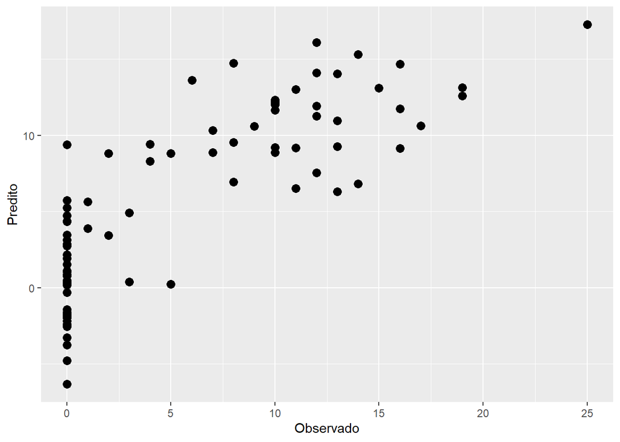

```r
# Plot do gráfico com valor predito x observado
fitted_lm %>%
  ggplot(aes(observado, .pred)) +
  geom_point(size = 3, col = "black") +
  labs(y = "Predito", x = "Observado")
```

### **Random Forest**

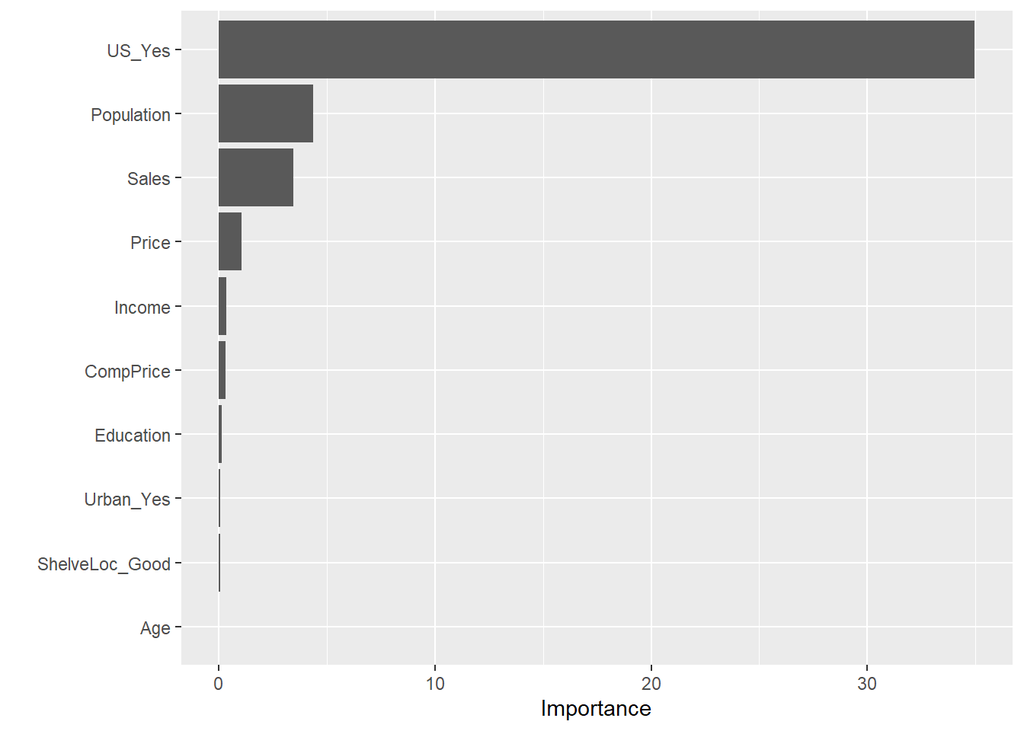

```r
rf_fit <- rand_forest() %>%
  set_engine("ranger", importance = "permutation") %>%
  set_mode("regression") %>%
  fit(Advertising ~ ., treinamento_proc)

# importancia variaveis: US_Yes, Sales e Population têm maior importância no modelo
vip(rf_fit)
```

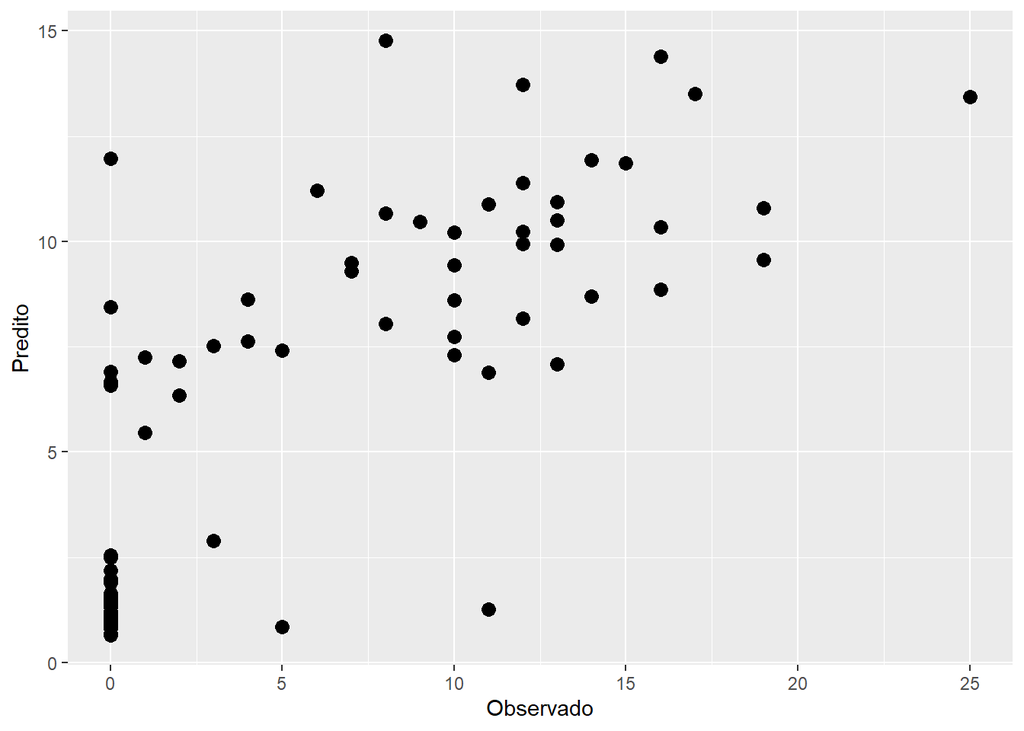

```r
fitted_rf <- rf_fit %>%
  predict(new_data = teste_proc) %>%
  mutate(observado = teste_proc$Advertising,
         modelo = "random forest")

fitted_rf %>%
  ggplot(aes(observado, .pred)) +
  geom_point(size = 3, col = "black") +
  labs(y = "Predito", x = "Observado")
```

### **KNN**

```r
knn_fit <- nearest_neighbor() %>%
  set_engine("kknn") %>%
  set_mode("regression") %>%
  fit(Advertising ~ ., treinamento_proc)


fitted_knn <- knn_fit %>%
  predict(new_data = teste_proc) %>%
  mutate(observado = teste_proc$Advertising,
         modelo = "kknn")

head(fitted_knn)
```

```
## # A tibble: 6 x 3
##   .pred observado modelo
##   <dbl>     <dbl> <chr>
## 1 13.1          4 kknn
## 2 10.7          0 kknn
## 3  5.53        11 kknn
## 4 19.5         11 kknn
## 5 15.8         13 kknn
## 6 11.8          0 kknn
```

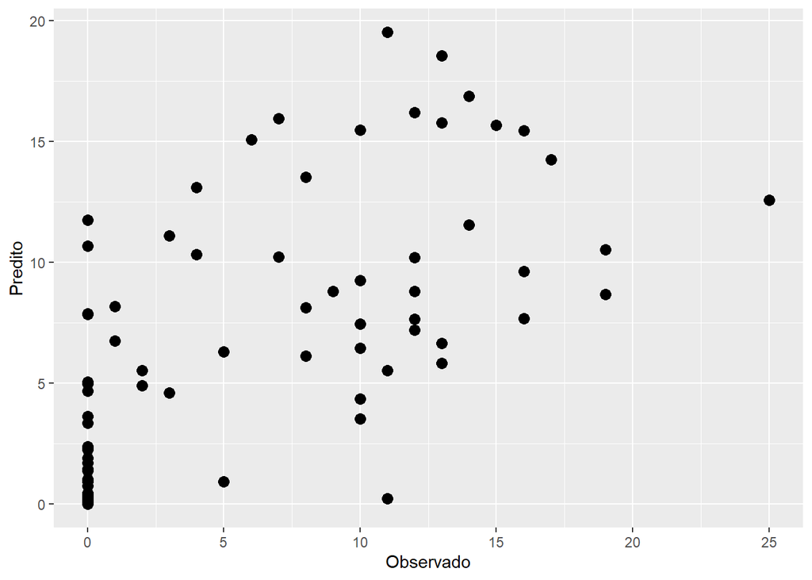

```r
fitted_knn %>%
  ggplot(aes(observado, .pred)) +
  geom_point(size = 3, col = "black") +
  labs(y = "Predito", x = "Observado")
```

### **XGBoost**

```r
xgb_fit <- boost_tree() %>%
  set_engine("xgboost") %>%
  set_mode("regression") %>%
  fit(Advertising ~ ., treinamento_proc)

fitted_xgb <- xgb_fit %>%
  predict(new_data = teste_proc) %>%
  mutate(observado = teste_proc$Advertising,
         modelo = "xgb")

head(fitted_xgb)
```

```
## # A tibble: 6 x 3
##   .pred observado modelo
##   <dbl>     <dbl> <chr>
## 1  4.22         4 xgb
## 2  6.30         0 xgb
## 3 11.1         11 xgb
## 4 10.3         11 xgb
## 5 12.4         13 xgb
## 6 14.5          0 xgb
```

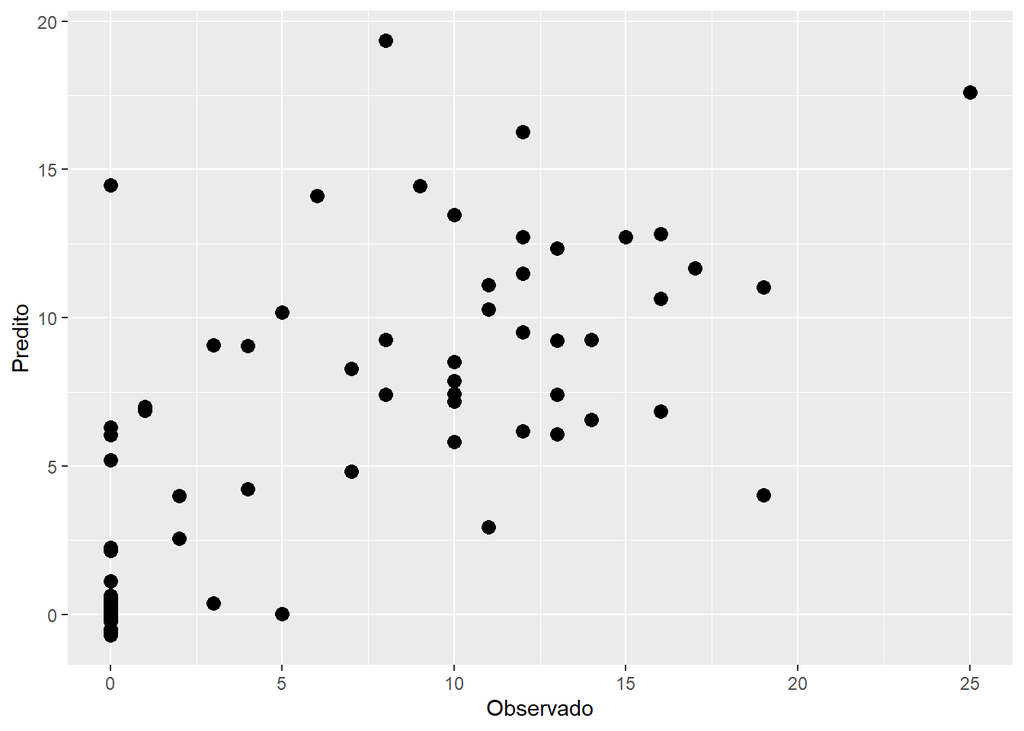

```r
fitted_xgb %>%
  ggplot(aes(observado, .pred)) +
  geom_point(size = 3, col = "black") +
  labs(y = "Predito", x = "Observado")
```